# Risk Factor Analysis

## Outcome Variable

**Outcome Variable:** sstunted

## Predictor Variables

**Intervention Variable:** exclfeed36

**Adjustment Set:**

unadjusted

## Stratifying Variables

The analysis was stratified on these variable(s):

- agecat
- studyid
- country

## Data Summary

| agecat | studyid | country | exclfeed36 | sstunted | n_cell | n |
| --- | --- | --- | --- | --- | --- | --- |
| Birth | CMC-V-BCS-2002 | INDIA | 1 | 0 | 3 | 3 |
| Birth | CMC-V-BCS-2002 | INDIA | 1 | 1 | 0 | 3 |
| Birth | CMC-V-BCS-2002 | INDIA | 0 | 0 | 0 | 3 |
| Birth | CMC-V-BCS-2002 | INDIA | 0 | 1 | 0 | 3 |
| Birth | EE | PAKISTAN | 1 | 0 | 2 | 7 |
| Birth | EE | PAKISTAN | 1 | 1 | 1 | 7 |
| Birth | EE | PAKISTAN | 0 | 0 | 4 | 7 |
| Birth | EE | PAKISTAN | 0 | 1 | 0 | 7 |
| Birth | GMS-Nepal | NEPAL | 1 | 0 | 409 | 526 |
| Birth | GMS-Nepal | NEPAL | 1 | 1 | 13 | 526 |
| Birth | GMS-Nepal | NEPAL | 0 | 0 | 101 | 526 |
| Birth | GMS-Nepal | NEPAL | 0 | 1 | 3 | 526 |
| Birth | IRC | INDIA | 1 | 0 | 0 | 4 |
| Birth | IRC | INDIA | 1 | 1 | 0 | 4 |
| Birth | IRC | INDIA | 0 | 0 | 4 | 4 |
| Birth | IRC | INDIA | 0 | 1 | 0 | 4 |
| Birth | JiVitA-3 | BANGLADESH | 1 | 0 | 7457 | 10681 |
| Birth | JiVitA-3 | BANGLADESH | 1 | 1 | 865 | 10681 |
| Birth | JiVitA-3 | BANGLADESH | 0 | 0 | 2103 | 10681 |
| Birth | JiVitA-3 | BANGLADESH | 0 | 1 | 256 | 10681 |
| Birth | JiVitA-4 | BANGLADESH | 1 | 0 | 1848 | 2517 |
| Birth | JiVitA-4 | BANGLADESH | 1 | 1 | 146 | 2517 |
| Birth | JiVitA-4 | BANGLADESH | 0 | 0 | 457 | 2517 |
| Birth | JiVitA-4 | BANGLADESH | 0 | 1 | 66 | 2517 |
| Birth | Keneba | GAMBIA | 1 | 0 | 358 | 1253 |
| Birth | Keneba | GAMBIA | 1 | 1 | 5 | 1253 |
| Birth | Keneba | GAMBIA | 0 | 0 | 871 | 1253 |
| Birth | Keneba | GAMBIA | 0 | 1 | 19 | 1253 |
| Birth | MAL-ED | BANGLADESH | 1 | 0 | 32 | 221 |
| Birth | MAL-ED | BANGLADESH | 1 | 1 | 0 | 221 |

[output cut: 162 more lines]

The following strata were considered:

- agecat: 24 months, studyid: CMC-V-BCS-2002, country: INDIA
- agecat: 24 months, studyid: EE, country: PAKISTAN
- agecat: 24 months, studyid: GMS-Nepal, country: NEPAL
- agecat: 24 months, studyid: IRC, country: INDIA
- agecat: 24 months, studyid: JiVitA-3, country: BANGLADESH
- agecat: 24 months, studyid: JiVitA-4, country: BANGLADESH
- agecat: 24 months, studyid: Keneba, country: GAMBIA
- agecat: 24 months, studyid: LCNI-5, country: MALAWI
- agecat: 24 months, studyid: MAL-ED, country: BANGLADESH
- agecat: 24 months, studyid: MAL-ED, country: BRAZIL
- agecat: 24 months, studyid: MAL-ED, country: INDIA
- agecat: 24 months, studyid: MAL-ED, country: NEPAL
- agecat: 24 months, studyid: MAL-ED, country: PERU
- agecat: 24 months, studyid: MAL-ED, country: SOUTH AFRICA
- agecat: 24 months, studyid: MAL-ED, country: TANZANIA, UNITED REPUBLIC OF
- agecat: 24 months, studyid: PROVIDE, country: BANGLADESH
- agecat: 6 months, studyid: CMC-V-BCS-2002, country: INDIA
- agecat: 6 months, studyid: EE, country: PAKISTAN
- agecat: 6 months, studyid: GMS-Nepal, country: NEPAL
- agecat: 6 months, studyid: IRC, country: INDIA
- agecat: 6 months, studyid: JiVitA-3, country: BANGLADESH
- agecat: 6 months, studyid: JiVitA-4, country: BANGLADESH
- agecat: 6 months, studyid: Keneba, country: GAMBIA
- agecat: 6 months, studyid: LCNI-5, country: MALAWI
- agecat: 6 months, studyid: MAL-ED, country: BANGLADESH
- agecat: 6 months, studyid: MAL-ED, country: BRAZIL
- agecat: 6 months, studyid: MAL-ED, country: INDIA
- agecat: 6 months, studyid: MAL-ED, country: NEPAL
- agecat: 6 months, studyid: MAL-ED, country: PERU
- agecat: 6 months, studyid: MAL-ED, country: SOUTH AFRICA
- agecat: 6 months, studyid: MAL-ED, country: TANZANIA, UNITED REPUBLIC OF
- agecat: 6 months, studyid: PROVIDE, country: BANGLADESH
- agecat: 6 months, studyid: SAS-FoodSuppl, country: INDIA
- agecat: Birth, studyid: CMC-V-BCS-2002, country: INDIA
- agecat: Birth, studyid: EE, country: PAKISTAN
- agecat: Birth, studyid: GMS-Nepal, country: NEPAL
- agecat: Birth, studyid: IRC, country: INDIA
- agecat: Birth, studyid: JiVitA-3, country: BANGLADESH
- agecat: Birth, studyid: JiVitA-4, country: BANGLADESH
- agecat: Birth, studyid: Keneba, country: GAMBIA
- agecat: Birth, studyid: MAL-ED, country: BANGLADESH
- agecat: Birth, studyid: MAL-ED, country: BRAZIL
- agecat: Birth, studyid: MAL-ED, country: INDIA
- agecat: Birth, studyid: MAL-ED, country: NEPAL
- agecat: Birth, studyid: MAL-ED, country: PERU
- agecat: Birth, studyid: MAL-ED, country: SOUTH AFRICA
- agecat: Birth, studyid: MAL-ED, country: TANZANIA, UNITED REPUBLIC OF
- agecat: Birth, studyid: PROVIDE, country: BANGLADESH

### Dropped Strata

Some strata were dropped due to rare outcomes:

- agecat: Birth, studyid: CMC-V-BCS-2002, country: INDIA
- agecat: Birth, studyid: EE, country: PAKISTAN
- agecat: Birth, studyid: GMS-Nepal, country: NEPAL
- agecat: Birth, studyid: IRC, country: INDIA
- agecat: Birth, studyid: MAL-ED, country: BANGLADESH
- agecat: Birth, studyid: MAL-ED, country: BRAZIL
- agecat: Birth, studyid: MAL-ED, country: INDIA
- agecat: Birth, studyid: MAL-ED, country: NEPAL
- agecat: Birth, studyid: MAL-ED, country: PERU
- agecat: Birth, studyid: MAL-ED, country: SOUTH AFRICA
- agecat: Birth, studyid: MAL-ED, country: TANZANIA, UNITED REPUBLIC OF
- agecat: Birth, studyid: PROVIDE, country: BANGLADESH
- agecat: 6 months, studyid: CMC-V-BCS-2002, country: INDIA
- agecat: 6 months, studyid: EE, country: PAKISTAN
- agecat: 6 months, studyid: IRC, country: INDIA
- agecat: 6 months, studyid: LCNI-5, country: MALAWI
- agecat: 6 months, studyid: MAL-ED, country: BANGLADESH
- agecat: 6 months, studyid: MAL-ED, country: BRAZIL
- agecat: 6 months, studyid: MAL-ED, country: INDIA
- agecat: 6 months, studyid: MAL-ED, country: NEPAL
- agecat: 6 months, studyid: MAL-ED, country: PERU
- agecat: 6 months, studyid: MAL-ED, country: SOUTH AFRICA
- agecat: 6 months, studyid: MAL-ED, country: TANZANIA, UNITED REPUBLIC OF
- agecat: 6 months, studyid: PROVIDE, country: BANGLADESH
- agecat: 6 months, studyid: SAS-FoodSuppl, country: INDIA
- agecat: 24 months, studyid: CMC-V-BCS-2002, country: INDIA
- agecat: 24 months, studyid: EE, country: PAKISTAN
- agecat: 24 months, studyid: IRC, country: INDIA
- agecat: 24 months, studyid: LCNI-5, country: MALAWI
- agecat: 24 months, studyid: MAL-ED, country: BANGLADESH
- agecat: 24 months, studyid: MAL-ED, country: BRAZIL
- agecat: 24 months, studyid: MAL-ED, country: INDIA
- agecat: 24 months, studyid: MAL-ED, country: NEPAL
- agecat: 24 months, studyid: MAL-ED, country: PERU
- agecat: 24 months, studyid: MAL-ED, country: SOUTH AFRICA
- agecat: 24 months, studyid: MAL-ED, country: TANZANIA, UNITED REPUBLIC OF

## Methods Detail

We’re interested in the causal parameters $E[Y_a]$ for all values of $a \in \mathcal{A}$. These parameters represent the mean outcome if, possibly contrary to fact, we intervened to set all units to have $A=a$. Under the randomization and positivity assumptions, these are identified by the statistical parameters $\psi_a=E_W[E_{Y|A,W}(Y|A=a,W)]$. In addition, we’re interested in the mean of $Y$, $E[Y]$ under no intervention (the observed mean). We will estimate these parameters by using SuperLearner to fit the relevant likelihood factors – $E_{Y|A,W}(Y|A=a,W)$ and $p(A=a|W)$, and then updating our likelihood fit using a joint TMLE.

For unadjusted analyses ($W=\{\}$), initial likelihoods were estimated using Lrnr_glm to estimate the simple $E(Y|A)$ and Lrnr_mean to estimate $p(A)$. For adjusted analyses, a small library containing Lrnr_glmnet, Lrnr_xgboost, and Lrnr_mean was used.

Having estimated these parameters, we will then use the delta method to estimate relative risks and attributable risks relative to a prespecified baseline level of $A$.

# Results Detail

## Results Plots

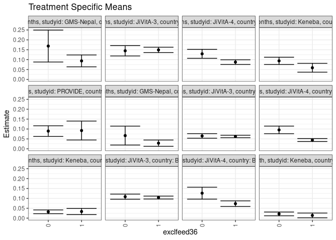

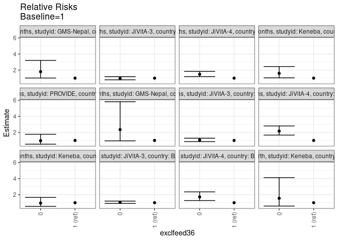

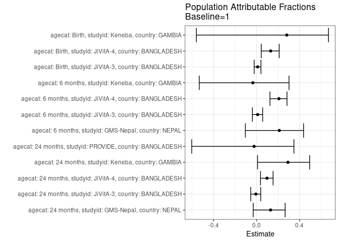

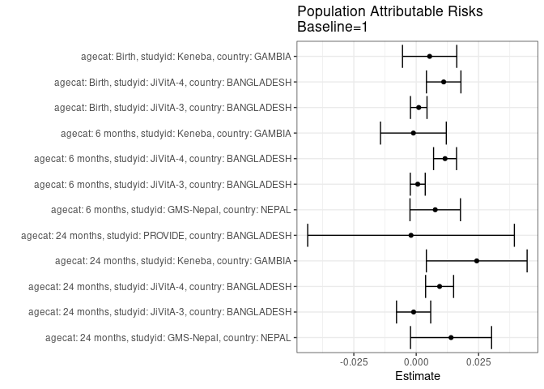

## Results Table

### Parameter: TSM

| agecat | studyid | country | intervention_level | baseline_level | estimate | ci_lower | ci_upper |
| --- | --- | --- | --- | --- | --- | --- | --- |
| Birth | JiVitA-3 | BANGLADESH | 1 | NA | 0.1039414 | 0.0966074 | 0.1112754 |
| Birth | JiVitA-3 | BANGLADESH | 0 | NA | 0.1085206 | 0.0955677 | 0.1214734 |
| Birth | JiVitA-4 | BANGLADESH | 1 | NA | 0.0732197 | 0.0590257 | 0.0874136 |
| Birth | JiVitA-4 | BANGLADESH | 0 | NA | 0.1261950 | 0.0960266 | 0.1563635 |
| Birth | Keneba | GAMBIA | 1 | NA | 0.0137741 | 0.0017794 | 0.0257688 |
| Birth | Keneba | GAMBIA | 0 | NA | 0.0213483 | 0.0118483 | 0.0308483 |
| 6 months | GMS-Nepal | NEPAL | 1 | NA | 0.0284360 | 0.0125625 | 0.0443096 |
| 6 months | GMS-Nepal | NEPAL | 0 | NA | 0.0666667 | 0.0189095 | 0.1144238 |
| 6 months | JiVitA-3 | BANGLADESH | 1 | NA | 0.0621770 | 0.0559329 | 0.0684210 |
| 6 months | JiVitA-3 | BANGLADESH | 0 | NA | 0.0648430 | 0.0533407 | 0.0763452 |
| 6 months | JiVitA-4 | BANGLADESH | 1 | NA | 0.0441222 | 0.0367800 | 0.0514644 |
| 6 months | JiVitA-4 | BANGLADESH | 0 | NA | 0.0953390 | 0.0761703 | 0.1145076 |
| 6 months | Keneba | GAMBIA | 1 | NA | 0.0335306 | 0.0178566 | 0.0492046 |
| 6 months | Keneba | GAMBIA | 0 | NA | 0.0319564 | 0.0223295 | 0.0415832 |
| 24 months | GMS-Nepal | NEPAL | 1 | NA | 0.0936639 | 0.0636576 | 0.1236702 |
| 24 months | GMS-Nepal | NEPAL | 0 | NA | 0.1686747 | 0.0880242 | 0.2493252 |
| 24 months | JiVitA-3 | BANGLADESH | 1 | NA | 0.1491729 | 0.1355479 | 0.1627980 |
| 24 months | JiVitA-3 | BANGLADESH | 0 | NA | 0.1446977 | 0.1185927 | 0.1708028 |
| 24 months | JiVitA-4 | BANGLADESH | 1 | NA | 0.0874404 | 0.0756739 | 0.0992069 |
| 24 months | JiVitA-4 | BANGLADESH | 0 | NA | 0.1294248 | 0.1067826 | 0.1520670 |
| 24 months | Keneba | GAMBIA | 1 | NA | 0.0589623 | 0.0365332 | 0.0813914 |
| 24 months | Keneba | GAMBIA | 0 | NA | 0.0938144 | 0.0754591 | 0.1121697 |
| 24 months | PROVIDE | BANGLADESH | 1 | NA | 0.0921986 | 0.0444047 | 0.1399925 |
| 24 months | PROVIDE | BANGLADESH | 0 | NA | 0.0894495 | 0.0626380 | 0.1162611 |

### Parameter: E(Y)

| agecat | studyid | country | intervention_level | baseline_level | estimate | ci_lower | ci_upper |
| --- | --- | --- | --- | --- | --- | --- | --- |
| Birth | JiVitA-3 | BANGLADESH | NA | NA | 0.1049527 | 0.0986146 | 0.1112909 |
| Birth | JiVitA-4 | BANGLADESH | NA | NA | 0.0842273 | 0.0714625 | 0.0969920 |
| Birth | Keneba | GAMBIA | NA | NA | 0.0191540 | 0.0115617 | 0.0267464 |
| 6 months | GMS-Nepal | NEPAL | NA | NA | 0.0360531 | 0.0201218 | 0.0519845 |
| 6 months | JiVitA-3 | BANGLADESH | NA | NA | 0.0627923 | 0.0572659 | 0.0683187 |
| 6 months | JiVitA-4 | BANGLADESH | NA | NA | 0.0556750 | 0.0484735 | 0.0628765 |
| 6 months | Keneba | GAMBIA | NA | NA | 0.0324022 | 0.0241972 | 0.0406072 |
| 24 months | GMS-Nepal | NEPAL | NA | NA | 0.1076233 | 0.0788298 | 0.1364169 |
| 24 months | JiVitA-3 | BANGLADESH | NA | NA | 0.1481311 | 0.1360218 | 0.1602403 |
| 24 months | JiVitA-4 | BANGLADESH | NA | NA | 0.0968140 | 0.0862351 | 0.1073930 |
| 24 months | Keneba | GAMBIA | NA | NA | 0.0832138 | 0.0687092 | 0.0977183 |
| 24 months | PROVIDE | BANGLADESH | NA | NA | 0.0901213 | 0.0667360 | 0.1135066 |

### Parameter: RR

| agecat | studyid | country | intervention_level | baseline_level | estimate | ci_lower | ci_upper |
| --- | --- | --- | --- | --- | --- | --- | --- |
| Birth | JiVitA-3 | BANGLADESH | 1 | 1 | 1.0000000 | 1.0000000 | 1.000000 |
| Birth | JiVitA-3 | BANGLADESH | 0 | 1 | 1.0440556 | 0.9078024 | 1.200759 |
| Birth | JiVitA-4 | BANGLADESH | 1 | 1 | 1.0000000 | 1.0000000 | 1.000000 |
| Birth | JiVitA-4 | BANGLADESH | 0 | 1 | 1.7235129 | 1.2660146 | 2.346337 |
| Birth | Keneba | GAMBIA | 1 | 1 | 1.0000000 | 1.0000000 | 1.000000 |
| Birth | Keneba | GAMBIA | 0 | 1 | 1.5498876 | 0.5828980 | 4.121050 |
| 6 months | GMS-Nepal | NEPAL | 1 | 1 | 1.0000000 | 1.0000000 | 1.000000 |
| 6 months | GMS-Nepal | NEPAL | 0 | 1 | 2.3444444 | 0.9454214 | 5.813725 |
| 6 months | JiVitA-3 | BANGLADESH | 1 | 1 | 1.0000000 | 1.0000000 | 1.000000 |
| 6 months | JiVitA-3 | BANGLADESH | 0 | 1 | 1.0428777 | 0.8518213 | 1.276787 |
| 6 months | JiVitA-4 | BANGLADESH | 1 | 1 | 1.0000000 | 1.0000000 | 1.000000 |
| 6 months | JiVitA-4 | BANGLADESH | 0 | 1 | 2.1607947 | 1.6669158 | 2.801002 |
| 6 months | Keneba | GAMBIA | 1 | 1 | 1.0000000 | 1.0000000 | 1.000000 |
| 6 months | Keneba | GAMBIA | 0 | 1 | 0.9530512 | 0.5465105 | 1.662011 |
| 24 months | GMS-Nepal | NEPAL | 1 | 1 | 1.0000000 | 1.0000000 | 1.000000 |
| 24 months | GMS-Nepal | NEPAL | 0 | 1 | 1.8008505 | 1.0127956 | 3.202090 |
| 24 months | JiVitA-3 | BANGLADESH | 1 | 1 | 1.0000000 | 1.0000000 | 1.000000 |
| 24 months | JiVitA-3 | BANGLADESH | 0 | 1 | 0.9699998 | 0.7925768 | 1.187140 |
| 24 months | JiVitA-4 | BANGLADESH | 1 | 1 | 1.0000000 | 1.0000000 | 1.000000 |
| 24 months | JiVitA-4 | BANGLADESH | 0 | 1 | 1.4801488 | 1.1914195 | 1.838849 |
| 24 months | Keneba | GAMBIA | 1 | 1 | 1.0000000 | 1.0000000 | 1.000000 |
| 24 months | Keneba | GAMBIA | 0 | 1 | 1.5910928 | 1.0373359 | 2.440459 |
| 24 months | PROVIDE | BANGLADESH | 1 | 1 | 1.0000000 | 1.0000000 | 1.000000 |
| 24 months | PROVIDE | BANGLADESH | 0 | 1 | 0.9701835 | 0.5330870 | 1.765670 |

### Parameter: PAR

| agecat | studyid | country | intervention_level | baseline_level | estimate | ci_lower | ci_upper |
| --- | --- | --- | --- | --- | --- | --- | --- |
| Birth | JiVitA-3 | BANGLADESH | 1 | NA | 0.0010114 | -0.0023023 | 0.0043250 |
| Birth | JiVitA-4 | BANGLADESH | 1 | NA | 0.0110076 | 0.0040987 | 0.0179165 |
| Birth | Keneba | GAMBIA | 1 | NA | 0.0053799 | -0.0054900 | 0.0162498 |
| 6 months | GMS-Nepal | NEPAL | 1 | NA | 0.0076171 | -0.0024945 | 0.0177287 |
| 6 months | JiVitA-3 | BANGLADESH | 1 | NA | 0.0006154 | -0.0023822 | 0.0036129 |
| 6 months | JiVitA-4 | BANGLADESH | 1 | NA | 0.0115528 | 0.0069503 | 0.0161554 |
| 6 months | Keneba | GAMBIA | 1 | NA | -0.0011283 | -0.0143127 | 0.0120560 |
| 24 months | GMS-Nepal | NEPAL | 1 | NA | 0.0139594 | -0.0022828 | 0.0302016 |
| 24 months | JiVitA-3 | BANGLADESH | 1 | NA | -0.0010419 | -0.0078926 | 0.0058088 |
| 24 months | JiVitA-4 | BANGLADESH | 1 | NA | 0.0093736 | 0.0037631 | 0.0149842 |
| 24 months | Keneba | GAMBIA | 1 | NA | 0.0242515 | 0.0040668 | 0.0444362 |
| 24 months | PROVIDE | BANGLADESH | 1 | NA | -0.0020773 | -0.0434866 | 0.0393321 |

### Parameter: PAF

| agecat | studyid | country | intervention_level | baseline_level | estimate | ci_lower | ci_upper |
| --- | --- | --- | --- | --- | --- | --- | --- |
| Birth | JiVitA-3 | BANGLADESH | 1 | NA | 0.0096363 | -0.0224881 | 0.0407515 |
| Birth | JiVitA-4 | BANGLADESH | 1 | NA | 0.1306892 | 0.0431871 | 0.2101892 |
| Birth | Keneba | GAMBIA | 1 | NA | 0.2808770 | -0.5597600 | 0.6684503 |
| 6 months | GMS-Nepal | NEPAL | 1 | NA | 0.2112746 | -0.1042928 | 0.4366642 |
| 6 months | JiVitA-3 | BANGLADESH | 1 | NA | 0.0098002 | -0.0391005 | 0.0563996 |
| 6 months | JiVitA-4 | BANGLADESH | 1 | NA | 0.2075050 | 0.1242079 | 0.2828796 |
| 6 months | Keneba | GAMBIA | 1 | NA | -0.0348228 | -0.5331853 | 0.3015467 |
| 24 months | GMS-Nepal | NEPAL | 1 | NA | 0.1297062 | -0.0313041 | 0.2655790 |
| 24 months | JiVitA-3 | BANGLADESH | 1 | NA | -0.0070335 | -0.0543920 | 0.0381979 |
| 24 months | JiVitA-4 | BANGLADESH | 1 | NA | 0.0968212 | 0.0364124 | 0.1534428 |
| 24 months | Keneba | GAMBIA | 1 | NA | 0.2914362 | 0.0087497 | 0.4935057 |
| 24 months | PROVIDE | BANGLADESH | 1 | NA | -0.0230496 | -0.6030206 | 0.3470885 |